# Multi-modal risk prediction model of PTSD

May 2020

## Background and Motivation

## Why multi-modal PTSD biomarker?

- PTSD is a prevalent and debilitating disorder resulting from a complex confluence of environmental and biological factors.
- Risk and resilience factors individually have small effect-size to be usefully predictive enough. A single modality is unlikely to be useful enough by itself.
- Hence, in order to build a robust PTSD biomarker, we have to integrate multiple heterogenous markers.
- Moreover, some markers might be more relevant to specific sub-population (etiological heterogeneity). Focusing on a single marker may miss relevant signal for some sub-population.
- Now if we are convinced of the need to a multi-modal predictor panel, the logical questions are:
  - What predictors to include in the panel?
  - How to incorporate information from these heterogenous signals?

## Two main approaches / road maps

- Previously we started with 1M heterogenous features and selected down to a 17 multi-omic marker panel [CITE].
- But this purely data-driven approach is limited by lack of sufficient sample size for a robust predictive model.
- An alternative (and complementary) approach is to start from a few (or single) markers and incrementally incorporate additional markers guided by prior knowledge as well as available data.
- We started from a genetic score and incorporate additional predictors incrementally.

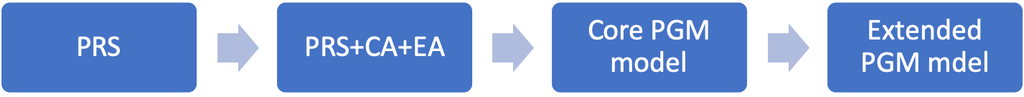

## Why start with genetic score?

- A substantial contribution of genetics to PTSD risk has been confirmed from early twin/family studies
- Unlike other molecular risk factors (such as other omics profiles) it does not have tissue specific patterns (very relevant for psychiatric biomarker).
- Third, it is a stable marker and technologies with reliable analytical validity are available to measure it accurately and inexpensively.
- Genetic data for most people will be available with no additional measurement cost and inconvenience
- External large-scale generic studies can be leveraged to train our predictive models. We can even incorporate GWAS results from genetically correlated disorders and traits.
- Can be assessed before trauma exposure

## Choosing other predictors

- Three main criteria:
  - literature evidence for a relatively large effect
  - pre-trauma risk factor like genetics
  - can be measured easily and accurately
- Accordingly, three predictors are studied in the first stage
  1. Polygenic risk (PRS)
  2. Childhood adversity (CA)
  3. Educational attainment (EA)

## Constructing PRS

- PRS computation was done using *pruning and thresholding* (P+T) approach as implemented on PRSice.
- GWAS summary statistic from PGC-PTSD (*freeze-2*) study was used.
  - European ancestry (23,212 cases and 151,447 control)
- *Imputation and QC* of samples and variants for all four cohorts were conducted separately.
  - Imputation is done with Ricopili, QC is done with PLINK and bash.
- PTSD status is the phenotype of interest, but the diagnosis method varies among the four cohort.
  - Level of trauma and time interval between trauma and assessment also differ among cohorts.

## Cohorts Description

| Dataset | SysBio | Ft. Campbell | GTP | AURORA |
| --- | --- | --- | --- | --- |
| Use | Training and Validation | Testing/ Replication | Testing/ Replication | Testing/ Replication |
| n | 270 | 1091 | 6229 | 1287 |
| Population | *Veterans* from Marines, Navy, Army and the Air Force | *Active-duty* Army personnel | *Civilian* recruited from primary care waiting room | *Civilian* recruited at emergency room |
| Diagnosis Score | CAPS | PCL | PTSS | PCL |
| Age: mean (sd) | 33.32 (8.25) | 27.75 (6.25) | 42.68 (153.22) | 35.46 (13.11) |
| BMI: mean (sd) | 28.22 (6.12) | 27.47 (3.7) |  | 30.31 (8.67) |

## Cohorts Description

- differ in ancestry and gender composition, case prevalence

SysBio FC GTP AURORA

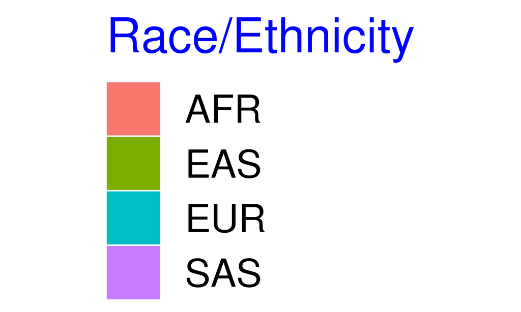

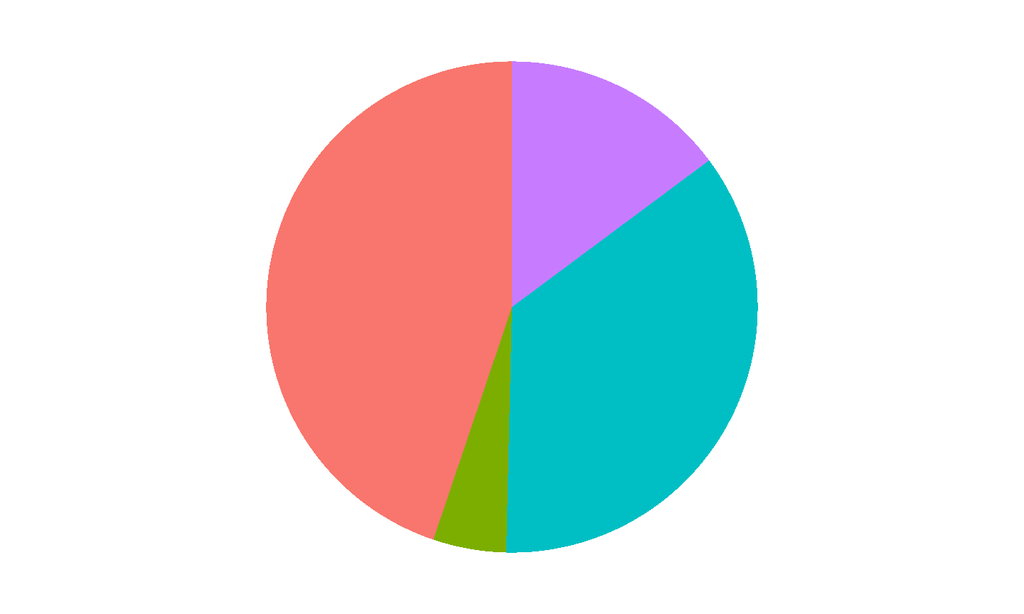

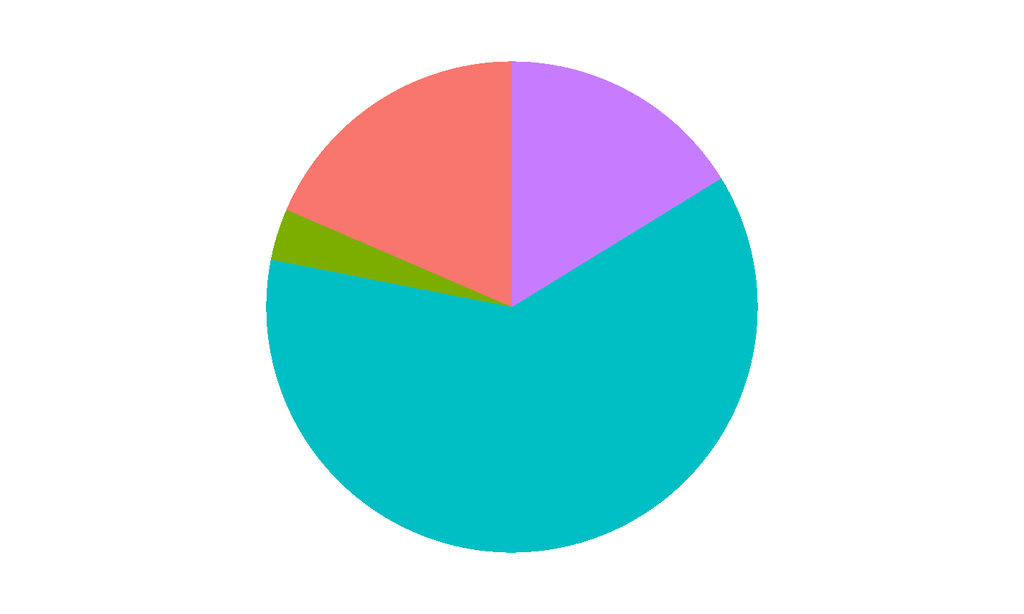

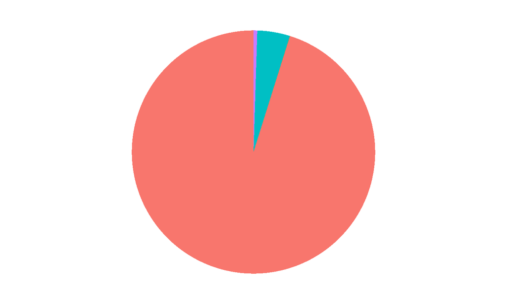

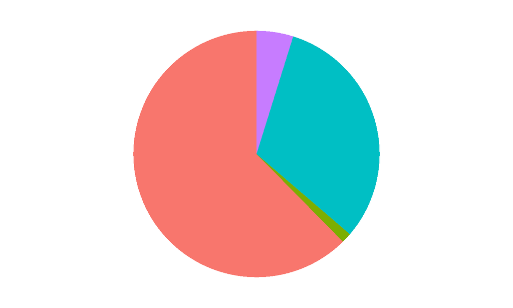

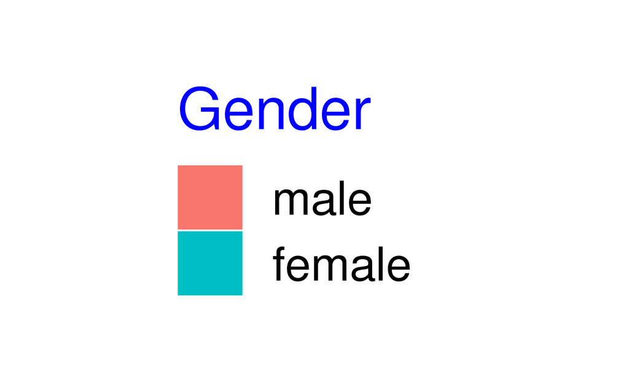

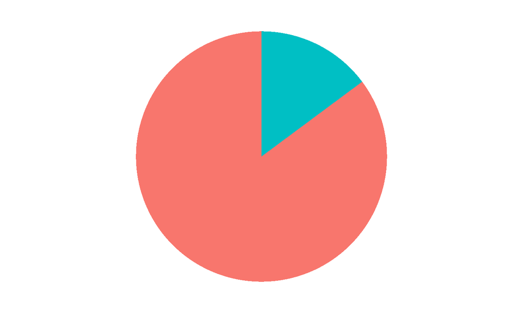

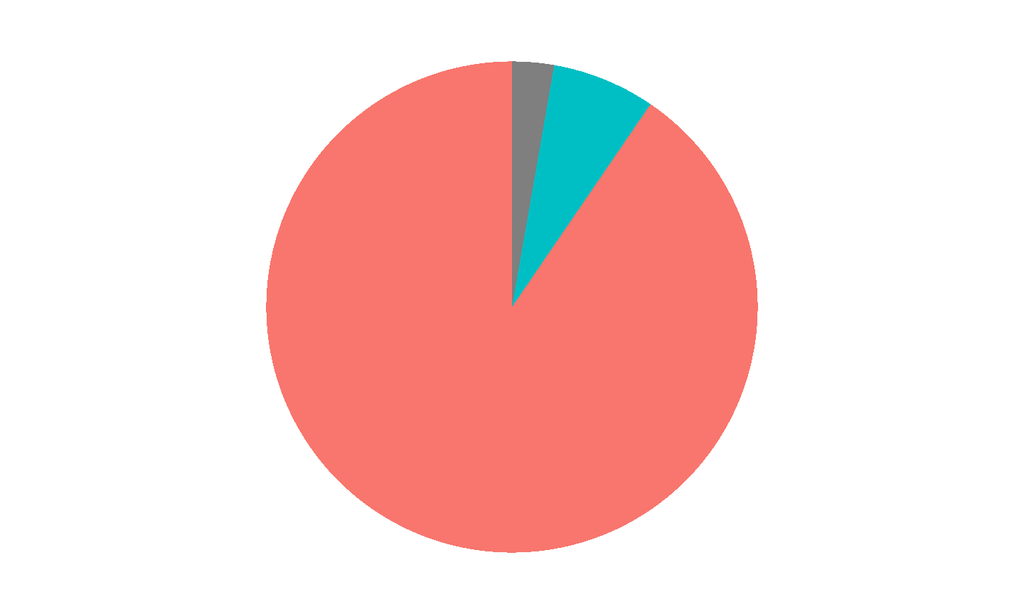

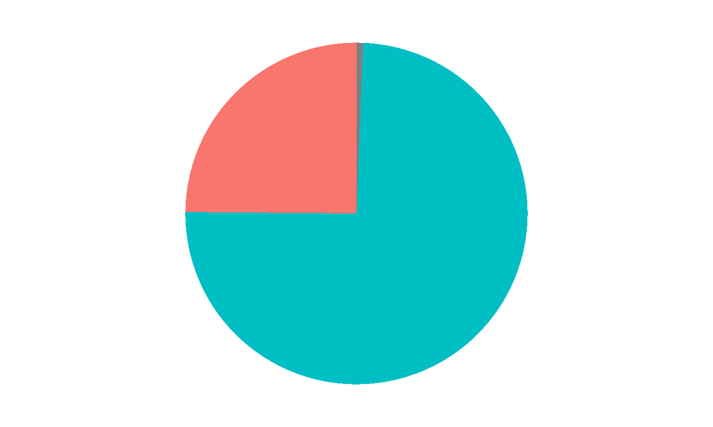

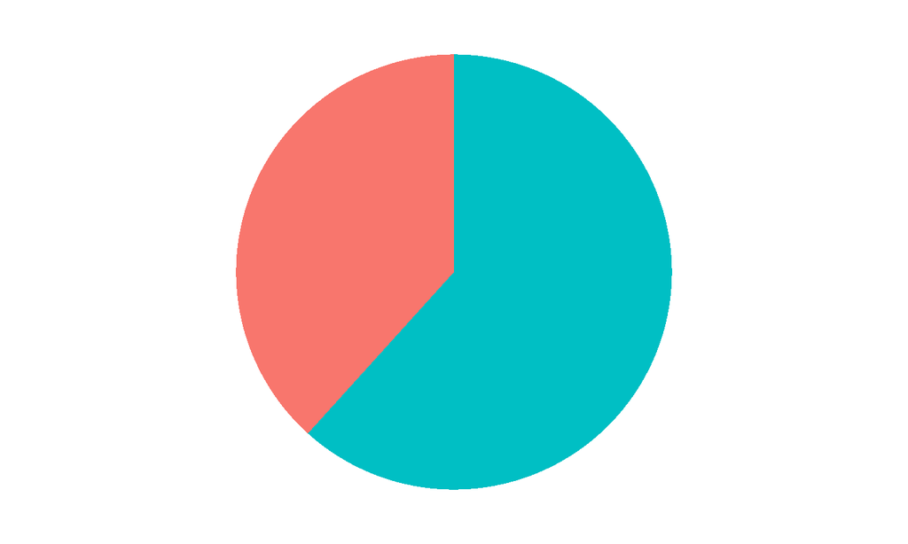

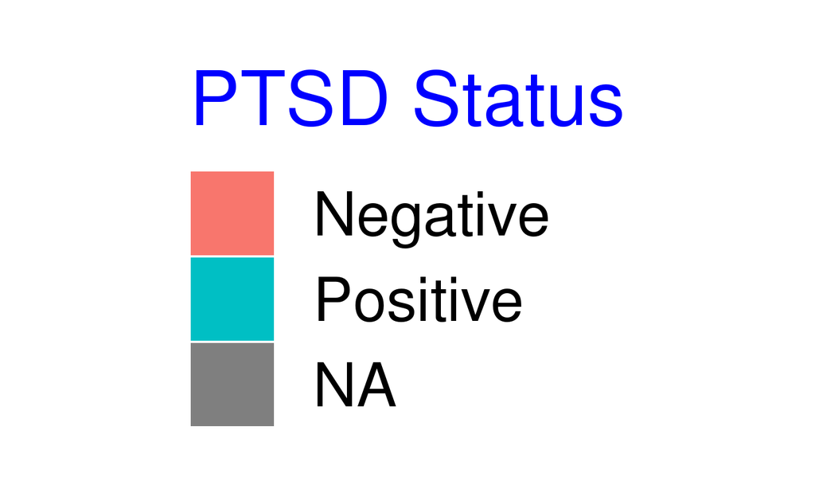

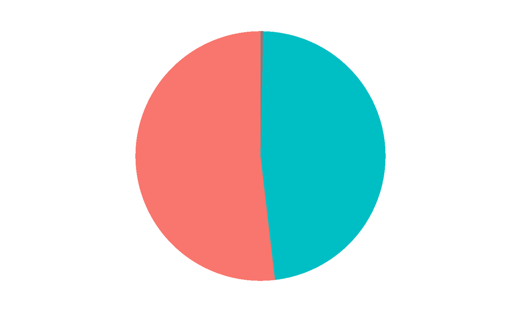

[3 more figures not shown]

## Building composite risk score of the three

## Overall Procedure

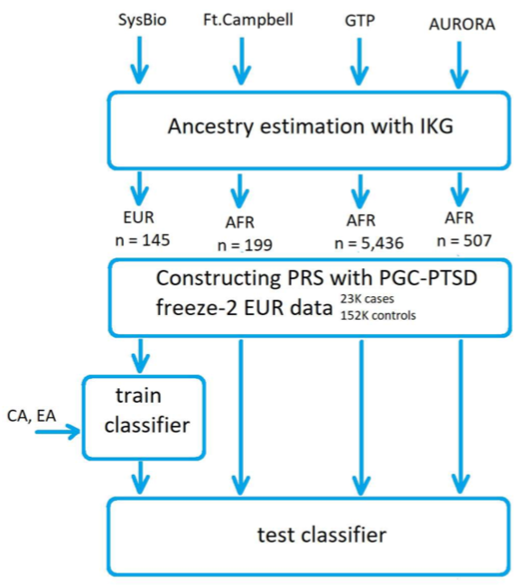

## Exploring classification algorithms

### Setup

- Independent discovery and replication cohorts:
  - Training cohort: SysBio (n=145)
  - Testing cohort: FC (n=199), GTP (n=5,436), AURORA (n=507)
- Response variable: PTSD diagnosis
- Predictor variables:
  - Discretizing predictors enables prediction across cohorts and results in a more interpretable model.
    - PRS (polygenic risk score discretized into four equally binned quantiles)
    - EA4 (educational attainment discretized to 4 levels: High sch. diploma, 2-yr assoc., Bachelor’s, graduate degree)
    - CA4 (childhood adversity discretized to 4 levels)

## Exploring classification algorithms

### Performance

|  | training/SysBio | testing1/FC | testing2/GTP | testing3/AURORA |
| --- | --- | --- | --- | --- |
| logistic regression | 0.686 | 0.641 | 0.615 | 0.576 |
| linear SVM | 0.673 | 0.635 | 0.637 | 0.559 |
| boosted trees | 0.712 | 0.563 | 0.575 | 0.601 |
| random forest | 0.782 | 0.624 | 0.588 | 0.594 |

## Logistic regression

\[ \mathbb{P}\left ( PTSD\mid PRS, CA, EA \right ) = \left [ 1 + \exp -\left ( \beta_{0} + \beta_{1}(PRS) + \beta_{2}(CA) + \beta_{3}(EA) \right ) \right ]^{-1} \]

where \[\beta_{0}=-0.425, \beta_{1}=0.163, \beta_{2}=0.459,\beta_{3}=-0.467 \]

## More on model performance

### PTSD status and severity

Replication datasets

|  | FC | GTP | AURORA |
| --- | --- | --- | --- |
| AUC | 0.6409774 | 0.6154428 | 0.5762484 |
| NagelkerkeR2 | 0.0310911 | 0.0666331 | 0.0124525 |
| OR | 2.9663549 | 3.7871976 | 1.4654363 |
| C-index | 0.5374116 | 0.5762403 | 0.5623298 |

## Summary and future work

- demonstrated a trivariate risk prediction model and tested it on three independent cohorts.
- lack of uniformity in assessment methods is a major challenge in replicating results across cohorts
- next steps includes incorporating additional predictor variables

## Extra

## Next steps

### Incorporate additional predictors

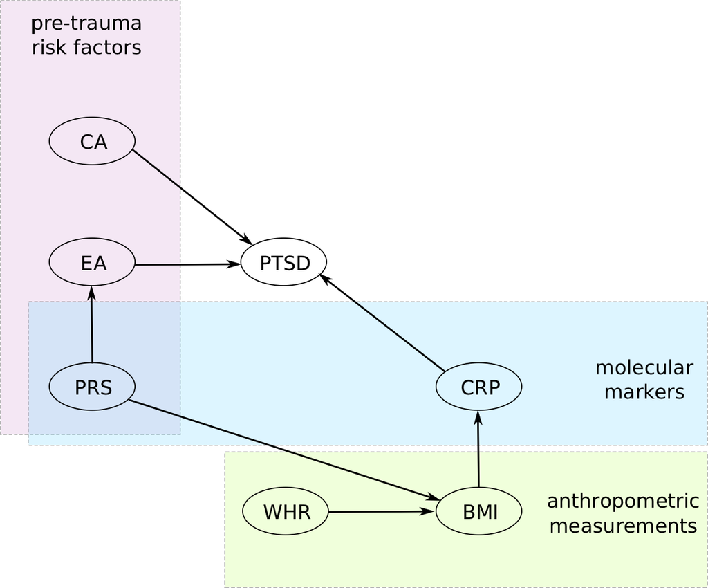

- a model with three more additional predictors
- a graphical model has several additional advantages over the ML methods discussed here

## Marginal effect

### Childhood trauma

[figure not shown]

## Marginal effect

### Educational attainment

[figure not shown]